# Aside

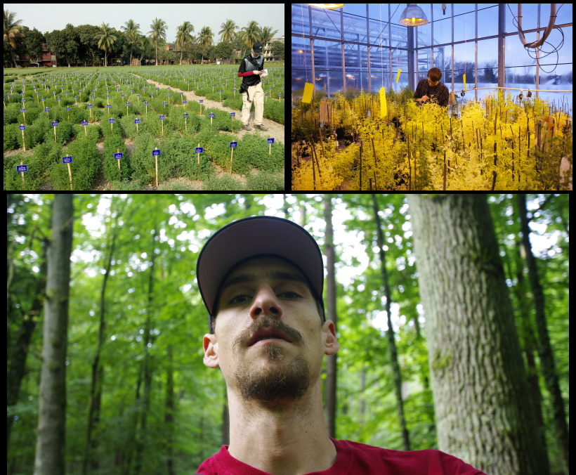

View CV as: [PDF](https://derekmichaelwright.github.io/dblogr/cv.wright.derek.pdf) [HTML](https://derekmichaelwright.github.io/dblogr/cv)

### Skills

- Photography
- Biology &Genomics
- Data Analytics & Visualization
- The R Project

### Contact

- +1 306-220-0645
- wrightmderek@gmail.com
- derek.wright@usask.ca
- /DerekMWright
- [/DerekMichaelWright](https://www.instagram.com/derekmichaelwright)
- .com/derekmichaelwright

### Website

derekmichaelwright.github.io/dblogr/

[figure not shown]

[figure not shown]

# Main

## Derek Michael Wright

I graduated with a **BSc in Biology** from the [*University of Regina*](https://www.uregina.ca/) in 2012, followed by a **MSc in Agrobiotechnology** from [*Justus-Liebig-Universität Gießen*](https://www.uni-giessen.de/) (*University of Giessen, Germany*) in 2015. I now work in the Plant Sciences department at the [*University of Saskatchewan*](https://www.usask.ca/) and have been involved in four research projects ([**AGILE**](https://knowpulse.usask.ca/study/2675314), [**EVOLVES**](https://knowpulse.usask.ca/study/2691111), [**P2IRC**](https://p2irc.usask.ca/index.php) & [**ACTIVATE**](https://activating-crops.usask.ca/)) with **lentil** (*Lens culinaris*).

I have done extensive work with a lentil diversity panel, NAM and inter-specific RIL populations. I am very fluent in and have plenty of experience with data analysis such as modeling, PCA, GxE, GWAS and QTL analyses. I have recently been working with data acquisition from UAV and seed imaging systems and can handle data wrangling and visualization of large, high-throughput data sets.

## Research Experience & Education

### University of Saskatchewan

Research Assistant

Saskatoon, Saskatchewan, Canada

Current - 2015

- Coordinate field trials
- Seed setup
- Post-harvest processing
- Data collection & analysis
- Presentations
- Collaborations

### Cargil Specialty Seeds and Oils

Research Assistant (Internship)

Aberdeen, Saskatchewan, Canada

2015

- Data collection & analysis
- Pathology (blackleg)

### M.Sc. in Agrobiotechnology

University of Giessen

Giessen, Hesse, Germany

2015 - 2013

- Biotechnology and Genomics
- Molecular Phytopathology
- Plant Microbe Interactions
- Plant Protection and Bioengeneering
- Microbial-Food-Biotechnology
- Applied Statistics and Bioinformatics
- Molecular Plant Breeding
- Molecular Entomology
- Tissue Culturing and Genetic Transformation

### B.Sc. Biology

University of Regina

Regina, Saskatchewan, Canada

2012 - 2007

- Limnology
- Environmental Microbiology
- Global Biogeochemistry
- Stable Isotope Ecology
- Vertebrate Animal Biology
- Advanced Plant Physiology
- Molecular Genetics
- Bacterial Genetics

## Packages

### gwaspr: an package for plotting GWAS results

https://derekmichaelwright.github.io/gwaspr/ devtools::install_github(“derekmichaelwright/gwaspr”)

N/A

N/A

### agData: an package containing agricultural data sets

https://derekmichaelwright.github.io/agData/ devtools::install_github(“derekmichaelwright/agData”)

N/A

N/A

## Publications

### Disecting lentil crop growth across multi-environment trials using unoccupied aerial vehicles and genome-wide association studies

[*The Plant Phenome Journal*. 8(1): e70040.](https://doi.org/10.1002/ppj2.70040)

N/A

2025

[github](https://github.com/derekmichaelwright/AGILE_LDP_UAV) [Script](https://derekmichaelwright.github.io/AGILE_LDP_UAV/LDP_UAV_Vignette.html)

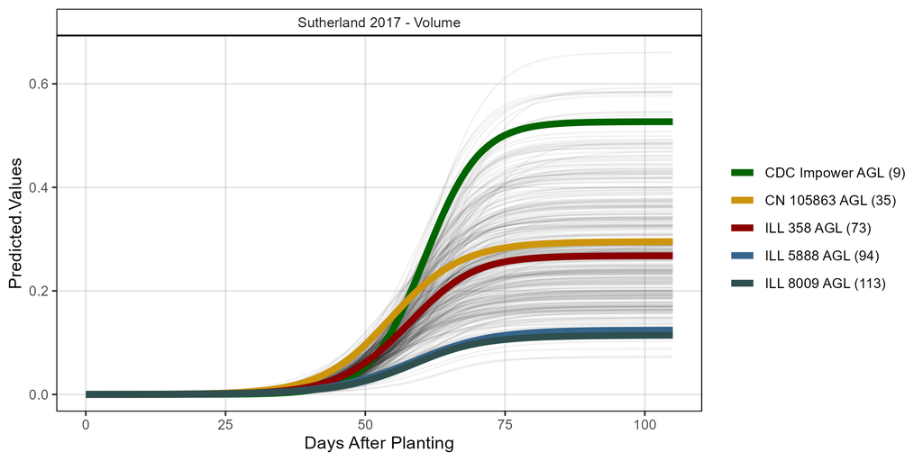

### Breeding potential of cultivated lentil for increased protein and amino acid concentrations in the Northern Great Plains

*Crop Science*. 65(3): e70085.

N/A

2025

[github](https://github.com/derekmichaelwright/AGILE_LDP_Protein) [Script](https://derekmichaelwright.github.io/AGILE_LDP_Protein/LDP_Protein_Vignette.html)

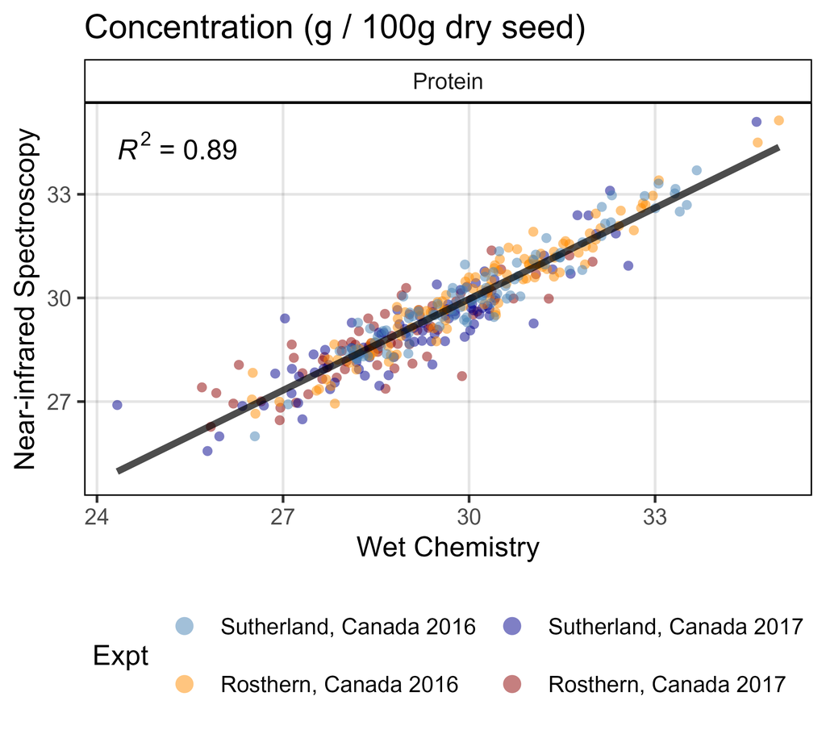

### Grazing preferences of three species of amoebae on cyanobacteria and green algae

[*The Journal of Eukaryotic Microbiology*. e13018: 1-14.](https://doi.org/10.1111/jeu.13018)

N/A

2024

### Mass Spectrometry-Based Untargeted Metabolomics Reveals the Importance of Glycosylated Flavones in Patterned Lentil Seed Coats

[*Journal of Agricultural and Food Chemistry*. 71(7): 3541–3549.](https://pubs.acs.org/doi/full/10.1021/acs.jafc.2c07844)

N/A

2023

### Focusing the GWAS *Lens* on days to flower using latent variable phenotypes derived from global multi-environment trials

[*The Plant Genome*. 16(1): e20269.](https://doi.org/10.1002/tpg2.20269)

N/A

2022

[github](https://github.com/derekmichaelwright/AGILE_LDP_GWAS_Phenology) [Script](https://derekmichaelwright.github.io/AGILE_LDP_GWAS_Phenology/GWAS_Phenology_Vignette.html)

[figure not shown]

### Strategic Identification of New Genetic Diversity to Expand Lentil (Lens culinaris Medik.) Production (Using Nepal as an Example)

[*Agronomy*. 11(10): 1933.](https://doi.org/10.3390/agronomy11101933)

N/A

2021

[github](https://github.com/derekmichaelwright/AGILE_LDP_Nepal) [Script](https://derekmichaelwright.github.io/AGILE_LDP_Nepal/Phenology_Vignette.html)

### Genomic selection for lentil breeding: Empirical evidence

[*The Plant Genome*. 13(1):e20002.](https://doi.org/10.1002/tpg2.20002)

N/A

2020

[figure not shown]

### Understanding photothermal interactions can help expand production range and increase genetic diversity of lentil (*Lens culinaris* Medik.)

[*Plants, People, Planet*. 3(2): 171-181.](https://doi.org/10.1002/ppp3.10158)

N/A

2020

[github](https://github.com/derekmichaelwright/AGILE_LDP_Phenology) [Script](https://derekmichaelwright.github.io/AGILE_LDP_Phenology/Phenology_Vignette.html)

### Influence of heterozygosity on nitrogen use efficiency in hybrid and purebred lines of *Brassica napus* (L.)

*University of Giessen MSc Thesis*

N/A

2015

[Script](https://derekmichaelwright.github.io/dblogr/publications/canola_nue/)

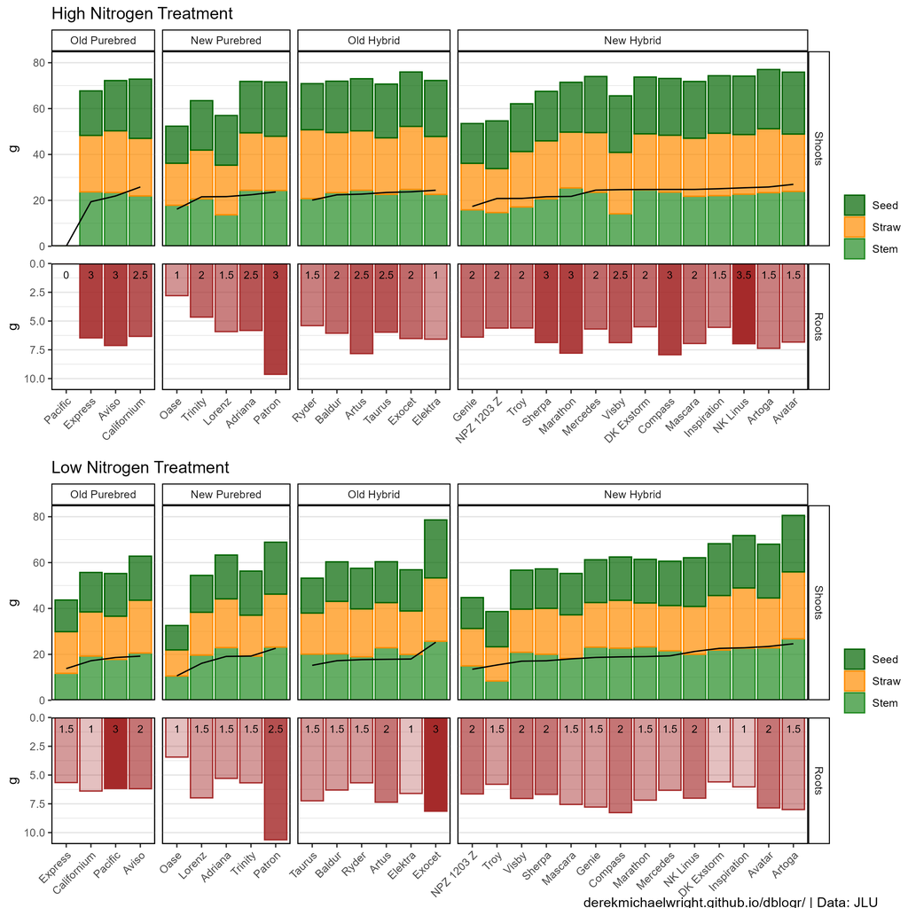

### Investigating seed size, shape, color, and patterning in a lentil using high throughput imaging

*unpublished*

N/A

N/A